# Sea otter seasonal diet composition in Southeast Alaska

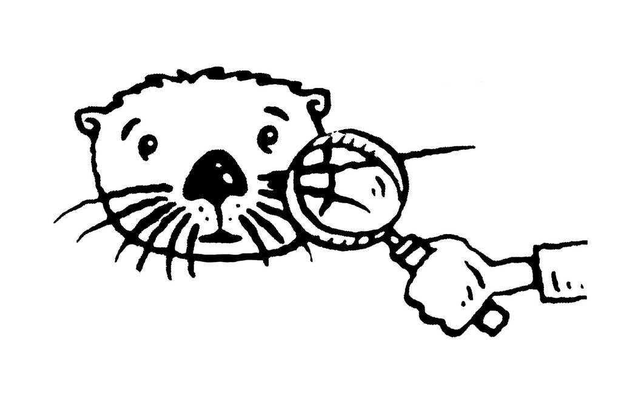

### Seasonal changes - Carbon

```r
cfit<-lm(Cr~distance*OtterID, whisk)
summary(cfit)
```

```
##
## Call:
## lm(formula = Cr ~ distance * OtterID, data = whisk)
##
## Residuals:
##      Min       1Q   Median       3Q      Max
## -2.09450 -0.19421  0.00586  0.22737  1.72301
##
## Coefficients:
##                        Estimate Std. Error t value Pr(>|t|)
## (Intercept)            -0.45226    0.30366  -1.489 0.137899
## distance                0.16216    0.09124   1.777 0.076964 .
## OtterID160480           1.18130    0.43087   2.742 0.006642 **
## OtterID163520           0.58651    0.41383   1.417 0.157895
## OtterID163521           0.23655    0.41607   0.569 0.570284
## OtterID163522           0.06469    0.41399   0.156 0.875977
## OtterID163523           0.54081    0.42017   1.287 0.199483
## OtterID163524           0.63623    0.42993   1.480 0.140416
## OtterID163525          -0.41719    0.41432  -1.007 0.315137
## OtterID163526           0.15180    0.42223   0.360 0.719564
## OtterID163527           0.23992    0.43026   0.558 0.577694
## OtterID163528           0.35176    0.42249   0.833 0.406030
## OtterID163529           1.43612    0.43553   3.297 0.001147 **
## OtterID163530           0.27045    0.42781   0.632 0.527959
## OtterID163531           0.49680    0.43291   1.148 0.252446
## OtterID163533           0.43120    0.45267   0.953 0.341906
## OtterID163534           1.19797    0.42494   2.819 0.005279 **
## OtterID163535           0.39743    0.42127   0.943 0.346562
## OtterID163536           0.88976    0.41419   2.148 0.032850 *
## OtterID77280            0.32268    0.41421   0.779 0.436844
## OtterID77281            0.38343    0.44190   0.868 0.386567
## OtterID77284            0.67743    0.41476   1.633 0.103909
## OtterID77285            0.27987    0.41487   0.675 0.500672
## OtterID77286            0.35695    0.42187   0.846 0.398457
## OtterID77287           -0.24113    0.43182  -0.558 0.577163
## OtterID77298            0.22277    0.41944   0.531 0.595910
## OtterID77299           -0.30311    0.42084  -0.720 0.472168
## OtterID77300           -0.14505    0.43468  -0.334 0.738951
## distance:OtterID160480 -0.42049    0.12887  -3.263 0.001288 **
## distance:OtterID163520 -0.20062    0.11387  -1.762 0.079570 .
```

[output cut: 15 more lines]

```
## distance:OtterID77280  -0.12524    0.11378  -1.101 0.272274
## distance:OtterID77281  -0.13511    0.14143  -0.955 0.340519
## distance:OtterID77284  -0.22735    0.11459  -1.984 0.048559 *
## distance:OtterID77285  -0.11428    0.11295  -1.012 0.312800
## distance:OtterID77286  -0.13247    0.11937  -1.110 0.268382
## distance:OtterID77287   0.08256    0.12902   0.640 0.522924
## distance:OtterID77298  -0.08954    0.11930  -0.751 0.453789
## distance:OtterID77299   0.06743    0.11783   0.572 0.567753
## distance:OtterID77300   0.04380    0.12870   0.340 0.733924
## ---
## Signif. codes:  0 '***' 0.001 '**' 0.01 '*' 0.05 '.' 0.1 ' ' 1
##
## Residual standard error: 0.4971 on 209 degrees of freedom
## Multiple R-squared:  0.2854, Adjusted R-squared:  0.1042
## F-statistic: 1.575 on 53 and 209 DF,  p-value: 0.01325
```

#### Here is the graph I used on the last poster. I do like it, but I think it takes explaining to understand what is going on.

Distance is time, and over time there is no change in the mean carbon.

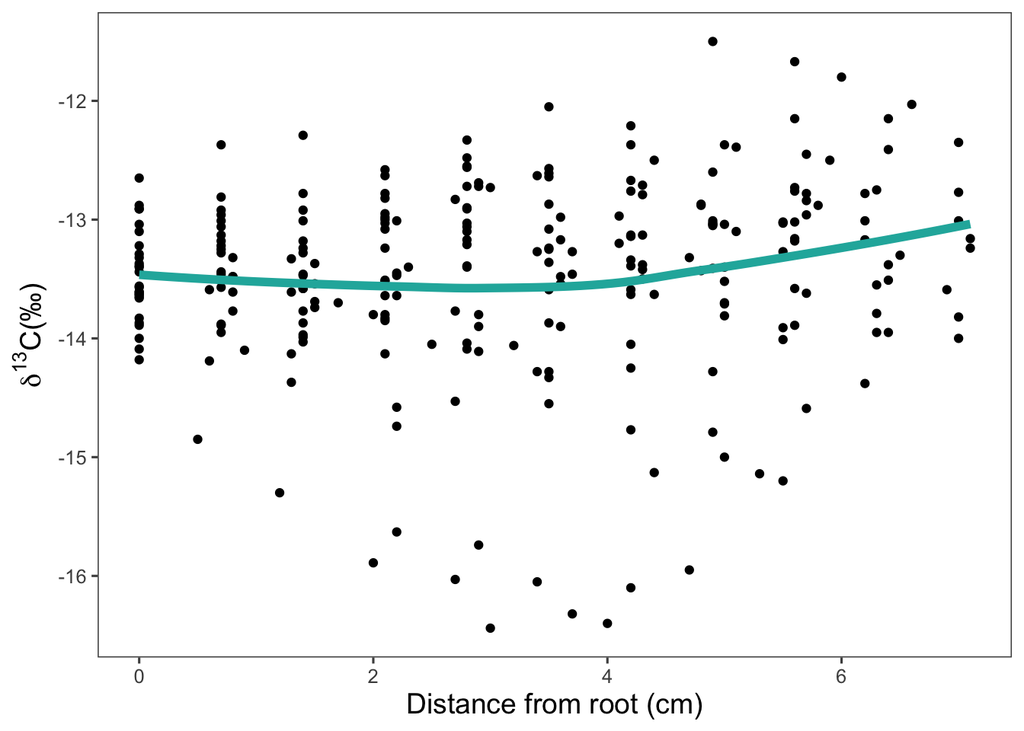

So I thought about how to portray this more simply, and also since my title says “seasonal” how to add in the seasonal aspect.

Here are histograms of carbon for each season. Overall, not much change.

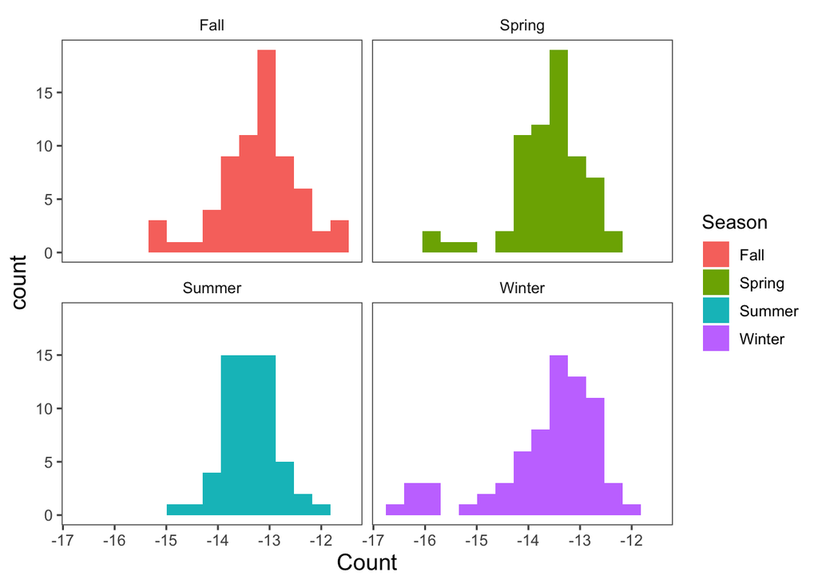

And then using density to smooth out the graphs, and overlay one on top of one another.

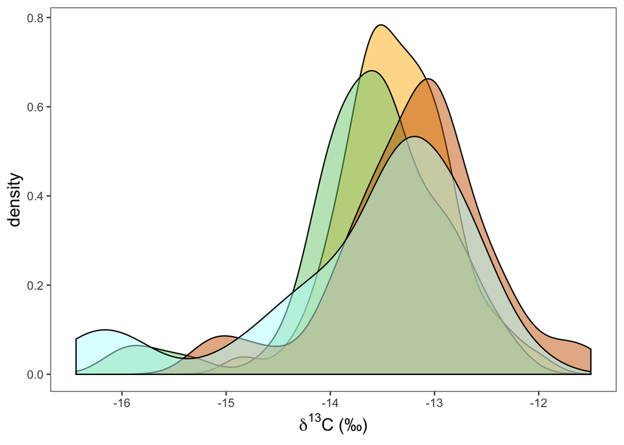

That is pretty messy, so I decided that Alaska really has two seasons - cold and warm. So here are the spring/summer months and the fall/winter months separated. Which is the final product that I am happy with.

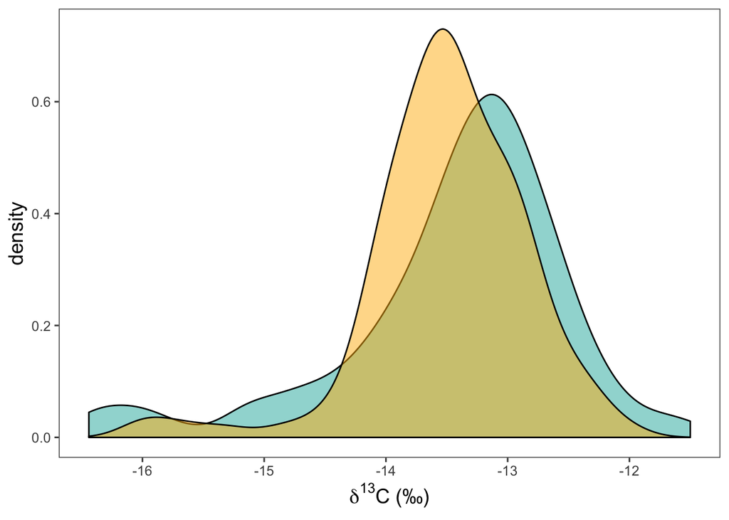

**Note that these need legends, I will get that on there

### Seasonal changes - Nitrogen

So Carbon has no real change over time, but Nitrogen tells a little different story

```r
nfit<-lm(Nr~distance*OtterID, whisk)
summary(nfit)
```

```
##
## Call:
## lm(formula = Nr ~ distance * OtterID, data = whisk)
##
## Residuals:
##      Min       1Q   Median       3Q      Max
## -1.40828 -0.20213 -0.01384  0.22011  1.06418
##
## Coefficients:
##                        Estimate Std. Error t value Pr(>|t|)
## (Intercept)            -0.70183    0.24144  -2.907 0.004045 **
## distance                0.25165    0.07254   3.469 0.000635 ***
## OtterID160480           0.78937    0.34259   2.304 0.022198 *
## OtterID163520           0.20508    0.32904   0.623 0.533783
## OtterID163521           0.59840    0.33082   1.809 0.071914 .
## OtterID163522           0.58609    0.32917   1.780 0.076448 .
## OtterID163523           0.25784    0.33408   0.772 0.441113
## OtterID163524           0.28854    0.34184   0.844 0.399591
## OtterID163525           0.79975    0.32943   2.428 0.016043 *
## OtterID163526           0.49501    0.33572   1.474 0.141861
## OtterID163527           0.64068    0.34210   1.873 0.062494 .
## OtterID163528           0.08136    0.33593   0.242 0.808872
## OtterID163529           0.88707    0.34629   2.562 0.011123 *
## OtterID163530           0.27603    0.34015   0.811 0.418002
## OtterID163531           0.41436    0.34421   1.204 0.230029
## OtterID163533           0.56241    0.35992   1.563 0.119659
## OtterID163534           0.53744    0.33788   1.591 0.113205
## OtterID163535           0.06754    0.33496   0.202 0.840407
## OtterID163536           0.45238    0.32933   1.374 0.171022
## OtterID77280            0.57594    0.32934   1.749 0.081800 .
## OtterID77281           -0.21333    0.35136  -0.607 0.544417
## OtterID77284            0.59513    0.32978   1.805 0.072573 .
## OtterID77285            0.57031    0.32987   1.729 0.085302 .
## OtterID77286            0.91946    0.33544   2.741 0.006654 **
## OtterID77287            0.03474    0.34335   0.101 0.919514
## OtterID77298            0.18953    0.33350   0.568 0.570428
## OtterID77299           -0.41952    0.33461  -1.254 0.211339
## OtterID77300            0.09244    0.34562   0.267 0.789382
## distance:OtterID160480 -0.28267    0.10247  -2.759 0.006319 **
## distance:OtterID163520 -0.10935    0.09054  -1.208 0.228503
```

[output cut: 15 more lines]

```
## distance:OtterID77280  -0.21578    0.09046  -2.385 0.017962 *
## distance:OtterID77281   0.10802    0.11245   0.961 0.337898
## distance:OtterID77284  -0.22076    0.09111  -2.423 0.016241 *
## distance:OtterID77285  -0.21512    0.08980  -2.395 0.017484 *
## distance:OtterID77286  -0.31945    0.09491  -3.366 0.000909 ***
## distance:OtterID77287  -0.01621    0.10258  -0.158 0.874618
## distance:OtterID77298  -0.08953    0.09486  -0.944 0.346341
## distance:OtterID77299   0.08918    0.09369   0.952 0.342252
## distance:OtterID77300  -0.04152    0.10233  -0.406 0.685357
## ---
## Signif. codes:  0 '***' 0.001 '**' 0.01 '*' 0.05 '.' 0.1 ' ' 1
##
## Residual standard error: 0.3953 on 209 degrees of freedom
## Multiple R-squared:  0.4016, Adjusted R-squared:  0.2499
## F-statistic: 2.647 on 53 and 209 DF,  p-value: 4.692e-07
```

This shows that distance is significant for the model `ln(N~distance*OtterID)` but the R^2 is still rather low.

For a comparison with the carbon graph above, here is the original Nitrogen graph used in the last poster.

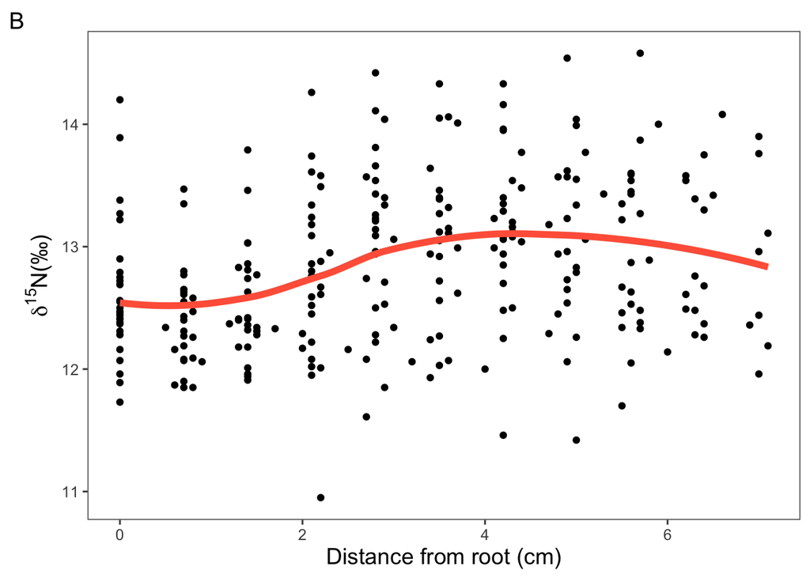

And here is the final product with two seasons

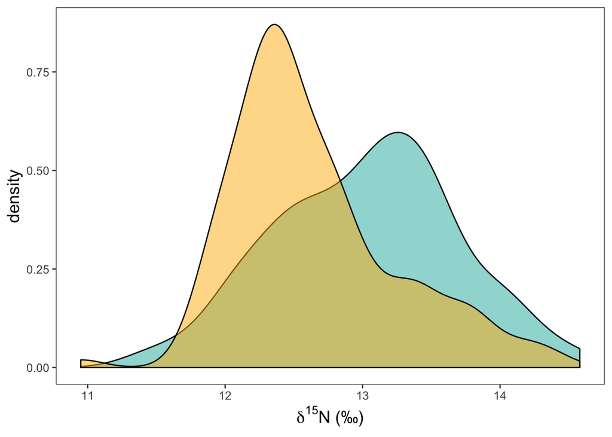

#### TAKEAWAY

There is a distinct difference with a much smaller overlap than the carbon graph, but the mean change is only 1 per mil. So, with that this is not showing a drastic trophic shift in prey, but more influenced by small ‘partial’ diet shifts. So otters are eating a lot of clams. They are always eating a lot of clams, but seasonally the other diet inputs can vary.

#### This is also interesting to add, the prey carbon and nitrogen values do not change over the seasons.

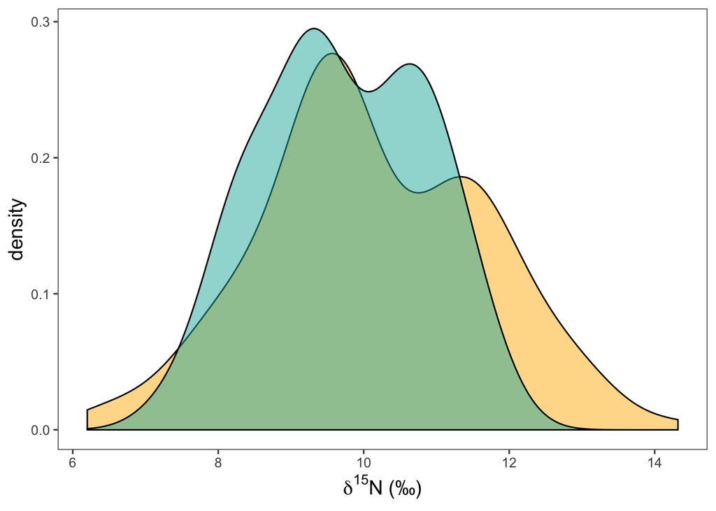

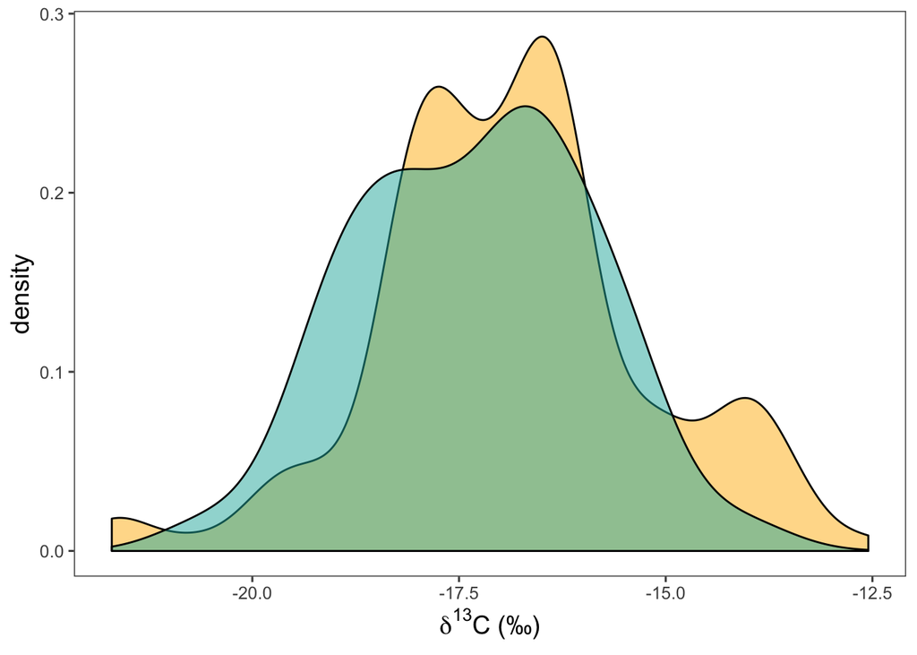